# Loan Data from Prosper

## by James Case

## Gather Data

Data was downloaded programtically from Udacity

## Univariate Exploration

> In this section I investigate distributions of individual variables. I will explore the most interesting distributions further with Bivariate Exploration. A full description of the graphs and points of interest can be found below.

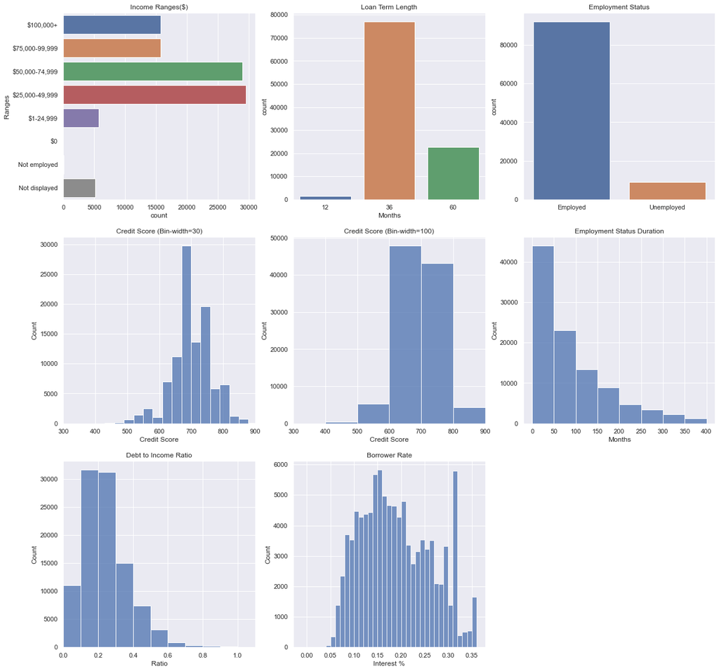

#### Income Ranges

- It is interesting that the distribution is unimodal, peaking at 25,000 to 74,999. This may suggest those with a lower income apply or are given loans more often.
- Unfortunately most of the individuals who had an income of 0 had multiple NaN categories and had to be removed. Further steps in investigating this dataset would involve reaching back to Prosper and finding out why.

#### Loan Term Length

- One common point I found in research was that loan companies would want to make their money back quickly so shorter loans would be desired. However, it appears there are not many 12 month loans and the majority belongs to 36 month loans.

#### Employment Status

- The majority of loans are given to those who are employed which makes sense as companies would want to know that those they are loaning to will be able to pay them back.

#### Credit Score

- It is interesting that there is a unimodal distribution centered around 670-700. This could suggest that those around this credit score are most likely to apply for a loan, or that the general population typically has a credit score near this range.

#### Debt To Income Ratio

- This graph largely shows that banks will loan money to individuals with a relatively low debt and avoid others with higher debt. There were a few outliers of individuals who had a ratio over 10, but they were removed.

#### Borrower Rate

- Borrower Rate has a fairly uniform distribution peaking around .15, but there is also a noticeable peark around .30.

## Bivariate Exploration

Here the variable that I am most interested in is what rate an individual got from Prosper based upon different paramters. Namely: Credit Score, Debt to Income Ratios, and Income Ranges. A full description of the plots can be found below.

#### Borrower Rate v Credit Score

Credit scores are determined by credit reporting agencies and are somewhat of a track record of your credit usage and history. The median rate individuals received decreases drastically as credit score goes up. It is not surprising that this happens as banks are more likely to loan to someone who has a better record, as they want to be apid back. What I find more interesting is the spread in data for credit scores in the low 600s to 700s. Here we can see that in these ranges it may be harder to predict what rate you may get because the distribution is fairly spread out. The violin plot shows this extremely well how above 700 credit score individuals are more likely to be near the median.

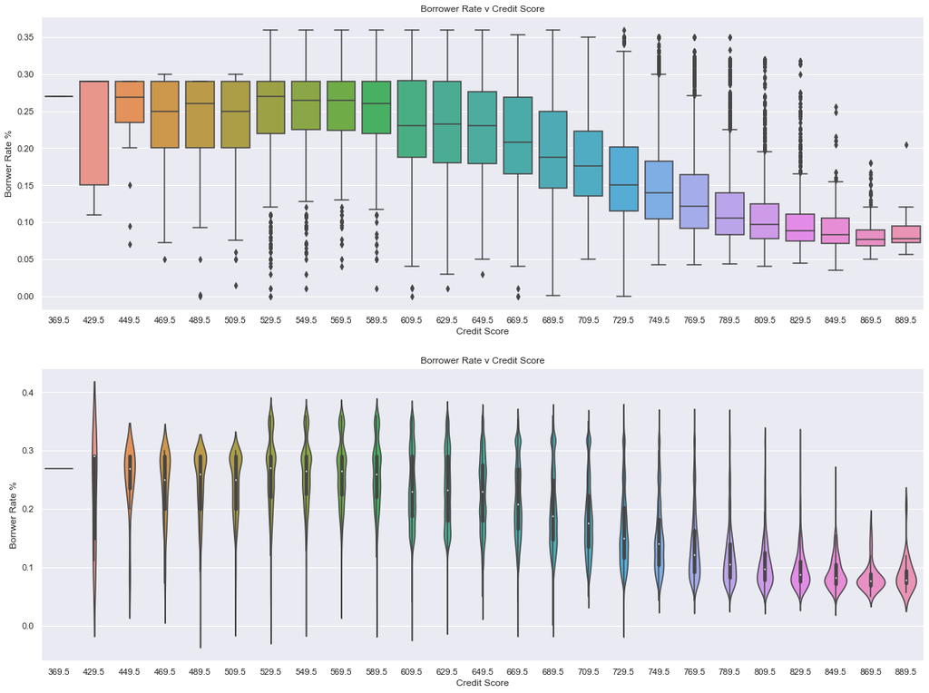

#### Borrower Rate v Debt to Income Ratio

The number of data points in this greatly affects the scatter plot and looks it extremely messy. The first set of scatter and kde plots only contain 10000 points, but it looks incomprehensible. In the second set of graphs only 1000 points were used and the fidelity of the graphs is not left.

The most interesting feature is in the kde plot where the majority of points are at a debt to income ratio of 0.2 resulting in a rate of 0.15. This is not clear in the scatter plot as their does not appear to be a relationship between the two. However, using the kde plot it would be ok to state that a majority of individuals that have a debt to income ratio close to 0.2 then it would be likely to have a rate of 0.15.

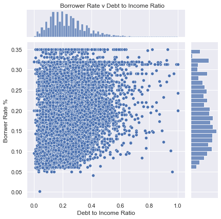

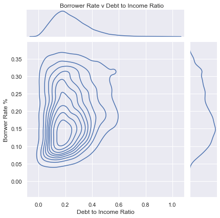

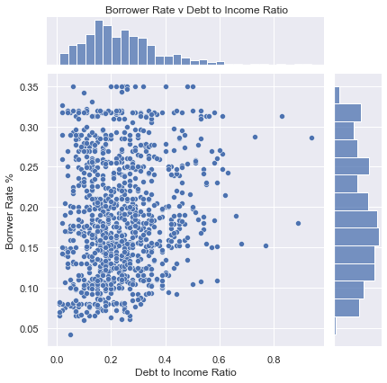

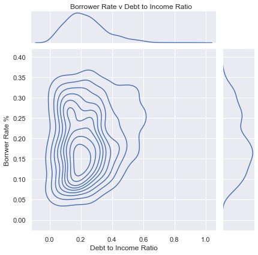

#### Borrower Rate v Income Ranges

The box plots below are showing that as income range decreases the median rate increases. This is interesting as it suggests those that have more money have an easier time finding loans. This is logical as banks will want to recoup their money faster and those with more moeny may be more likely to pay it back faster. However, it does not help those who have a lower income and may be more in need of a loan.

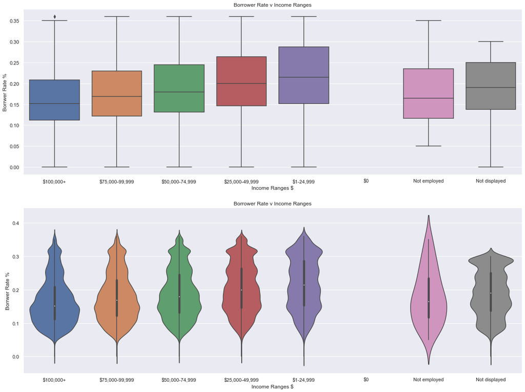

## Multivariate Exploration

Here I am most interested in how other variables affect the relationship between an individual's debt to income ratio and their loan rate.

#### Employments Affect on Borrower Rate

To begin with the data was havily skewed in banks providing people with loans who were employed rather than being unemployed. Despite this, it is interesting to note that in the kde plot the unemployed individuals are still getting around the same rates as employed people with the same debt to income ratio.

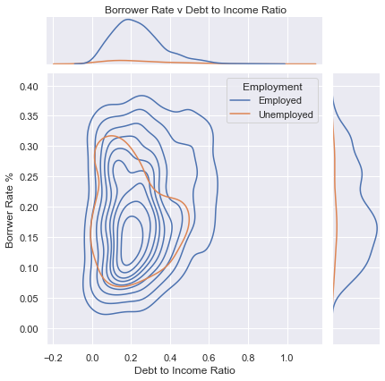

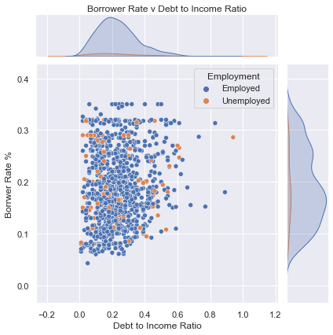

#### Loan Term Length Affect on Borrower Rate

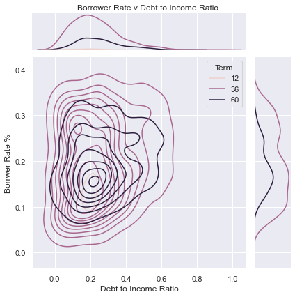

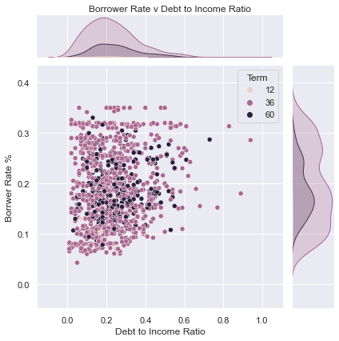